# 1. Introduction

The global financial market, in the past decades, has suffered from several unprecedented crises: Dot-com bubble (2000-2002), Global Financial Crisis (2007-2009), Greek government-debt crisis (2009-now), etc. Despite the complexity of their causes, almost all of those crises shared a similar driver which is the inability of governments, financial institutions and investors to assess and control credit risk.

What exactly is credit risk? In general, it is the risk that a borrower fails to meet his/her obligated payment for the debt. The reason can be due to either a fraud or the borrowers facing financial hardship or disruption in cash flow, etc.

Effective methods to quantify credit risk are becoming more and more vital for financial institutions. Value-at-Risk (VaR) is perhaps the most common risk measure in banking industry ever since it was integrated into the Basel Accord as a requirement to assess capital adequacy. VaR basically means the potential loss within a predefined confidence interval over a time horizon. Despite its popularity, this technique suffers from two major drawbacks such as it is not always sub-additive and it cannot measure the loss beyond VaR. Thus, CVaR (Conditional Value-at-Risk, Average Value-at-Risk or Expected shortfall) was introduced as an extension of VaR to measure extreme loss (loss that goes beyond VaR).

In this report, we put an effort into understanding the practice application of the two aforementioned measures: VaR and CVaR. In addition, we attempt to study two aspects of expected loss that were suggested in Basel II, the chance that borrowers not paying (Probability of default - PD) and the loss amount in case of default (Loss given default - LGD).

Given the scope of this report, all data are presumed. We then apply Monte Carlo method alongside with some of its techniques to simulate probabilistic events and study their effects on the preceding measurements of our presupposed portfolios.

# 2. Analysis result

## 2.1. Risk of a single stock

### 2.1.1. A stock's probability of default

In this section, we study the odds that a single company defaults. Merton model (1974) considers bankruptcy as the event that a company's total asset is lower than its total debt at a specific date. A way to assess its total asset value is to evaluate its stock price which is assumed to follow a geometric Brownian motion: \begin{equation} S_{t+\Delta t}=S*t \exp\Big(\sigma W*{\Delta t}+\Big(r-\frac{\sigma^2}{2}\Big)\Delta t\Big) \tag{1} \end{equation}

Figure 1 displays the stock evolution based on 100 simulations over the given period T=1 year under different threshold value B=100,50,36 respectively.

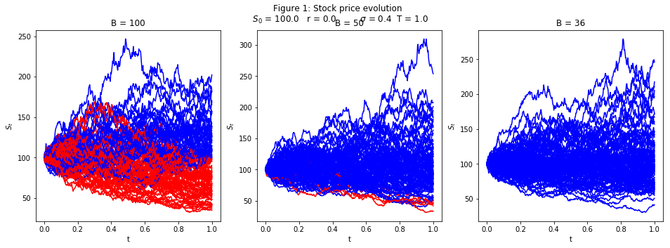

```python
import numpy as np
import pandas as pd
import matplotlib.pyplot as plt

Nmc = 100
So = 100.0
B = [100.0, 50.0, 36.0]
sigma = 0.4
r = 0.0
T = 1.0
t = np.linspace(0,T,np.int(T*365.0)+1)
dt = 1.0/365.0

def evolve(So,r,sigma,dt):
    seed = np.random.normal()
    S = So*np.exp((r-0.5*sigma**2)*dt+sigma*dt**0.5*seed)
    return S, seed

S = np.zeros((Nmc,int(T*365)+1))
w = np.zeros((Nmc,int(T*365)+1))

plt.subplots(figsize=(16,5))
for b in range(0,len(B)):
    plt.subplot(1, 3, b+1)
    for n in range(0,Nmc):
        S[n,0] = So
        for i in range(0,np.int(T*365.0)):
            S[n,i+1], w[n,i] = evolve(S[n,i],r,sigma,dt)

        if S[n,-1] < B[b]:
            plt.plot(t, S[n,:], 'red')
        else:
            plt.plot(t, S[n,:], 'blue')
    plt.xlabel('t')
    plt.ylabel(r'$S_t$')
    plt.title(r'B = %d' %B[b])

plt.suptitle('Figure 1: Stock price evolution \n ' + r'$S_0$ = ' + str(So) + '\t r = ' +str(r) + '\t $\sigma$ = ' +str(sigma) + '\t T = '+ str(T))
plt.show()
```

The red lines indicate the paths that the year-end stock price is lower than the given threshold ($S_T < B$) while the blue lines indicates the other case. It is easy to notice that the lower the threshold, the fewer the red lines. This goes in line with the outcome in Table 1 which presents the probability of default under a threshold B. This estimation is the result of 10,000 Monte Carlo simulation.

\begin{equation} P(S_T < B) = \frac{1}{N_{mc}}\sum\limits_{i=1}^{N_{mc}} 1_{S_T < B} \tag{2} \end{equation}

```python
Nmc = 10000
So = 100.0
B = [100.0, 50.0, 36.0]
sigma = 0.4
r = 0.0
T = 1.0
t = np.linspace(0,T,np.int(T*365.0)+1)
dt = 1.0/365.0


S = np.zeros((Nmc,int(T*365)+1))
w = np.zeros((Nmc,int(T*365)+1))

pd_table = pd.DataFrame(columns = ['B', 'PD'])
pd_table['B']= B

for b in range(0,len(B)):
    for n in range(0,Nmc):
        S[n,b] , w[n,b] = evolve(So,r,sigma,T)

    pd_table.iloc[b,1] = sum(1.0 for s in S[:,0] if s < B[b])/float(Nmc)

print('Table 1: 1 Stock - Threshold B and Probability of Default')
print(pd_table)
```

```
Table 1: 1 Stock - Threshold B and Probability of Default
       B      PD
0  100.0  0.5813
1   50.0   0.065
2   36.0  0.0088
```

### 2.1.2. Loss from a single stock

We define the loss on this stock as $X=S_T-B$. Figure 2 shows that the loss follows log-normal distribution. This is a direct result from the fact that $S_T$ is log-normal distributed and B is a constant parameter. Moreover, threshold B only affects the mean value but not the shape of the distribution. Figure 2 clarifies this statement as the density functions are identical in shape but each peaks differently.

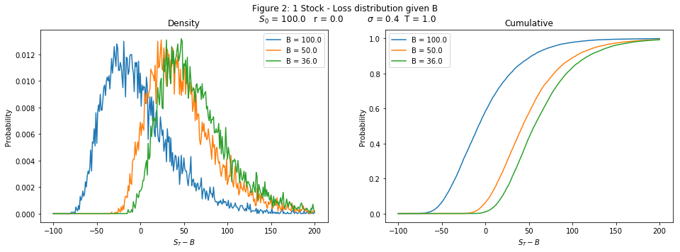

```python
Nmc = 10000
So = 100.0
B = [100.0, 50.0, 36.0]
sigma = 0.4
r = 0.0
T = 1.0
t = np.linspace(0,T,np.int(T*365.0)+1)
dt = 1.0/365.0
X = np.linspace(-100, 200, 301)

# S = np.zeros((Nmc,int(T*365.0)+1))
density = np.zeros((301,len(B)))
cumul = np.zeros((301,len(B)))

for b in range(0,len(B)):
#     for n in range(0,Nmc):
#         S[n,b] , w[n,b] = evolve(So,r,sigma,T)
    for x in range(0,len(X)):
        density[x,b] = sum(1.0 for s in S[:,b] if (s - B[b] <= X[x] + 1) & (s - B[b] > X[x]))/float(Nmc)
        cumul[x,b] = sum(1.0 for s in S[:,b] if s - B[b] <= X[x])/float(Nmc)

plt.subplots(figsize=(16,5))
plt.subplot(1,2,1)
plt.plot(X, density)
plt.xlabel(r'$S_T-B$')
plt.ylabel('Probability')
plt.title('Density')
plt.legend(['B = ' +str(B[0]),'B = ' +str(B[1]),'B = ' +str(B[2])])

plt.subplot(1,2,2)
plt.plot(X, cumul)
plt.xlabel(r'$S_T-B$')
plt.ylabel('Probability')
plt.title('Cumulative')
plt.legend(['B = ' +str(B[0]),'B = ' +str(B[1]),'B = ' +str(B[2])])

plt.suptitle('Figure 2: 1 Stock - Loss distribution given B \n ' + r'$S_0$ = ' + str(So) + '\t r = ' +str(r) + '\t $\sigma$ = ' +str(sigma) + '\t T = '+ str(T))
plt.show()
```

### 2.1.3. Value at Risk and Conditional Value at Risk

We take a further look at each case and estimate its VaR at different $\alpha$ by 3 methods: (i) analytical method, (ii) sorting method and (iii) Robbins-Monro stochastic approximation. After that, CVaR will be calculated using the following formular: \begin{equation} CVaR*\alpha=E\Big[X \big| X\leq VaR*\alpha\Big] \tag{3} \end{equation}

##### Analytical method

For a single stock, this method is rather simple to calculate and easy to understand as we know the loss distribution is log-normal. However, for a portfolio of stocks or options, this method is difficult due to complicated distribution function. Hence, we only run this method for a single stock. \begin{align} &&P(S_T-B \leq VaR) &=\alpha &\ &\iff& P\bigg(W_T \leq \frac{1}{\sigma}\Big(\ln \frac{VaR+B}{S_0}- \big(r-\frac{\sigma^2}{2}\big)T\Big)\bigg) &=\alpha\ &\iff& \frac{1}{\sigma\sqrt{T}}\Big(\ln \frac{VaR+B}{S_0}- \big(r-\frac{\sigma^2}{2}\big)T\Big) &=\mathcal{N}^{-1}(\alpha)\ &\iff& S_0\exp\bigg(\sigma\sqrt{T}\mathcal{N}^{-1}(\alpha)+\Big(\big(r-\frac{\sigma^2}{2}\big)T\Big)\bigg)-B &= VaR \tag{4} \end{align}

```python
from scipy.stats import norm

var_a = pd.DataFrame(columns = ['alpha', 'B', "T (days)", 'VaR'])

T=[1.0, 10.0/365.0]
alpha = [0.1, 0.01, 0.001]

for a in alpha:
    for Ti in T:
        for b in B:
            var_a = var_a.append(pd.DataFrame([[a, b, Ti*365.0,  evolve(So,r,sigma,Ti)[0] - b]],
                         columns = ['alpha', 'B', "T (days)", 'VaR']))

print('Table 2: 1 Stock - VaR estimation by Analytical method')
print(pd.pivot_table(data = var_a, values = 'VaR', columns = 'alpha', index = ["T (days)",'B']).transpose())
```

[output not shown]

##### Sorting method

Sorting method allows us to estimate VaR as the $\alpha^{th}$-quantile of an ascending ordered sequence of the simulated loss X. \begin{equation} VaR*{\alpha}(X)=X*{\left \lfloor{\alpha N_{mc}}\right \rfloor} \tag{5} \end{equation}

This method is much simpler than analytical method and works for any distribution. One thing to consider regarding this method is its precision when we want to estimate VaR at extremely low $\alpha$.

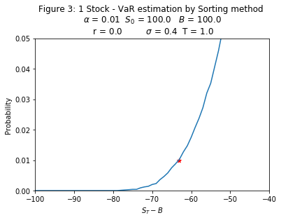

```python
plt.plot(X, cumul[:,0])
plt.scatter(np.sort(S[:,0])[int(alpha[1]*float(Nmc))] - B[0], alpha[1], marker = '*', color = 'r')
plt.xlim((-100,-40))
plt.ylim((0,0.05))
plt.xlabel(r'$S_T-B$')
plt.ylabel('Probability')
plt.title('Figure 3: 1 Stock - VaR estimation by Sorting method \n' r'$\alpha$ = ' + str(alpha[1]) + '\t $S_0$ = ' + str(So) + '\t $B$ = ' + str(B[0]) + '\n r = ' +str(r) + '\t $\sigma$ = ' +str(sigma) + '\t T = '+ str(T[0]))
```

```python
var_s = pd.DataFrame(columns = ['alpha', 'B', "T (days)", 'VaR'])

for a in alpha:
    for Ti in T:
        for b in range(0,len(B)):
            var_s = var_s.append(pd.DataFrame([[a, B[b], Ti*365.0,  np.sort(S[:,b])[int(a*float(Nmc))] - B[b]]],
                         columns = ['alpha', 'B', "T (days)", 'VaR']))


cvar_s = pd.DataFrame(columns = ['alpha', 'B', "T (days)", 'CVaR'])

for a in alpha:
    for Ti in T:
        for b in range(0,len(B)):
            loss = S[:, b] - B[b]
            cvar_s = cvar_s.append(pd.DataFrame([[a, B[b], Ti*365.0,  loss[loss < var_s[(var_s['alpha'] == a) & (var_s['B'] == B[b]) & (var_s["T (days)"] == Ti*365.0)]['VaR'].values].mean()]],
                         columns = ['alpha', 'B', "T (days)", 'CVaR']))

print('Table 3: 1 Stock - VaR estimation by Sorting method')
print(pd.pivot_table(data = var_s, values = 'VaR', columns = 'alpha', index = ["T (days)",'B']).transpose())

print('\n Table 4: 1 Stock - CVaR estimation by Sorting method')
print(pd.pivot_table(data = cvar_s, values = 'CVaR', columns = 'alpha', index = ["T (days)",'B']).transpose())
```

```
Table 3: 1 Stock - VaR estimation by Sorting method
T (days)      10.0                             365.0
B             36.0       50.0       100.0      36.0       50.0       100.0
alpha
0.001     -7.812435 -21.872221 -72.525732  -7.812435 -21.872221 -72.525732
0.010      0.490781 -12.679477 -63.211891   0.490781 -12.679477 -63.211891
0.100     19.671587   5.658504 -45.330704  19.671587   5.658504 -45.330704

 Table 4: 1 Stock - CVaR estimation by Sorting method
T (days)      10.0                             365.0
B             36.0       50.0       100.0      36.0       50.0       100.0
alpha
0.001    -11.107345 -25.315659 -74.812366 -11.107345 -25.315659 -74.812366
0.010     -3.799403 -16.853800 -67.461140  -3.799403 -16.853800 -67.461140
0.100     10.708293  -3.322632 -53.717942  10.708293  -3.322632 -53.717942
```

##### Robbins-Monro stochastic approximation

Estimating VaR by Robbins-Monro algorithm is the most challenging method among the three as we need to choose a "good step" ($\beta$) and a starting point ($z_0$) that is rationally near the true value for the approximating process. The theory tells us to transform the probability in form of expectation of indicator function:

\begin{equation} P(X\leq VaR)=\alpha \iff E[1_{X\leq VaR}-\alpha]=0 \tag{6} \end{equation}

Then, the sequence converges in probability to VaR. \begin{equation} VaR*\alpha (X) = \lim\limits*{n \to \infty} z*n - \gamma*{n+1}(1_{X\leq z_n}-\alpha) \tag{7} \end{equation}

where

\begin{equation} \gamma_n=\frac{\beta}{(n+1)^\lambda} \text{ we take $\lambda = 0.9$} \tag{8} \end{equation}

As for $\beta$, we decide to take automate guess as $1/\alpha,10/\alpha,100/\alpha$. Figure 4 demonstrates our test at different $\beta$ and it turns out that this method produces the similar result with two other methods.

```
VaR = -60.86
```

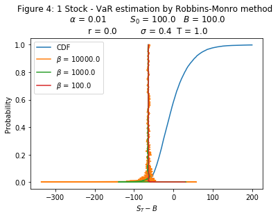

```python
from math import log

Nmc = 50000
beta = [100.0/alpha[1], 10.0/alpha[1], 1.0/alpha[1]]
lamda = 0.9
d = 100.0
zo = 30.0

def phi(z,x):
    if x <= z:
        return 1.0
    else:
        return 0.0

var_rb = np.zeros((Nmc+1,len(beta)))
for beta_i in range(0,len(beta)):
    var_rb[0,beta_i] = zo
    s = 0
    for n in range(0,Nmc):
        gamma = beta[beta_i]/(n+2)**lamda
        var_rb[n+1,beta_i] = var_rb[n,beta_i] - gamma*(phi(var_rb[n,beta_i], evolve(So,r,sigma,T[0])[0]- B[0]) - alpha[1])

        if (var_rb[n+1,beta_i] >= -d*log(1+s)) & (var_rb[n+1,beta_i] <= d*log(1+s)):
            s = s
        else:
            var_rb[n+1,beta_i]=var_rb[0, beta_i]
            s = s+1

plt.plot(X, cumul[:,0])
plt.plot(var_rb, np.linspace(0,1,Nmc+1))
plt.xlabel(r'$S_T-B$')
plt.ylabel('Probability')
plt.legend(['CDF', r'$\beta$ = '+str(beta[0]), r'$\beta$ = '+str(beta[1]), r'$\beta$ = '+str(beta[2]) ])
plt.title('Figure 4: 1 Stock - VaR estimation by Robbins-Monro method \n ' + r'$\alpha$ = ' + str(alpha[1]) + '\t $S_0$ = ' + str(So) + '\t $B$ = ' + str(B[0]) + '\n r = ' +str(r) + '\t $\sigma$ = ' +str(sigma) + '\t T = '+ str(T[0]))

print('VaR = ' + str(np.round(var_rb[-1,0],2)))
```

```python
Nmc = 10000
lamda = 0.9
d = 100.0
zo = 30.0

var_rb = pd.DataFrame(columns = ['alpha', 'B', "T (days)", 'VaR'])
cvar_rb = pd.DataFrame(columns = ['alpha', 'B', "T (days)", 'CVaR'])

for a in alpha:
    for Ti in T:
        for b in range(0,len(B)):
            z = np.zeros((Nmc+1,1))
            loss = np.zeros((Nmc,1))
            z[0] = zo
            s = 0
            for n in range(0,Nmc):
                gamma = beta[0]/(n+2)**lamda
                loss[n] = evolve(So,r,sigma,Ti)[0]- B[b]
                z[n+1] = z[n] - gamma*(phi(z[n], loss[n]) - a)

                if (z[n+1] >= -d*log(1+s)) & (z[n+1] <= d*log(1+s)):
                    s = s
                else:
                    z[n+1] = z[0]
                    s = s+1
            var_rb = var_rb.append(pd.DataFrame([[a, B[b], Ti*365.0,  z[-1]]],
                         columns = ['alpha', 'B', "T (days)", 'VaR']))

            cvar_rb = cvar_rb.append(pd.DataFrame([[a, B[b], Ti*365.0,  loss[loss < var_rb[(var_rb['alpha'] == a) & (var_rb['B'] == B[b]) & (var_rb["T (days)"] == Ti*365.0)]['VaR'].values].mean()]],
                         columns = ['alpha', 'B', "T (days)", 'CVaR']))


print('Table 5: 1 Stock - VaR estimation by Robbins Monro method')
print(pd.pivot_table(data = var_s, values = 'VaR', columns = 'alpha', index = ["T (days)",'B']).transpose())

print('\n Table 6: 1 Stock - CVaR estimation by Robbins Monro method')
print(pd.pivot_table(data = cvar_s, values = 'CVaR', columns = 'alpha', index = ["T (days)",'B']).transpose())
```

```
C:\Program Files\Anaconda3\lib\site-packages\ipykernel_launcher.py:29: RuntimeWarning: Mean of empty slice.
```

[output not shown]

A major trouble of classic Monte Carlo simulation method is that it fails to tell us the information of the tail of a distribution, which is severely small. A way to tackle this issue is to adopt Important Sampling method to get a sufficient amount of samples from another distribution.

\begin{align} E\Big[\phi (W_T)\Big] &=\int_R \phi (x) \frac{1}{\sqrt{2\pi T}}e^{-x^2/2T}dx\\ &=\int_R \phi (x) \frac{1}{\sqrt{2\pi T}}e^{-x^2/2T}e^{-(x-\theta T)^2/2T}e^{(x+\theta T)^2/2T}dx\\ &=\int_R \phi (x) e^{-\theta Tx+\frac{\theta^2 T}{2}}\frac{1}{\sqrt{2\pi T}}e^{-(x-\theta T)^2/2T}dx\\ &=E_Q\Big[\phi (\bar{W}_T) e^{-\theta \bar{W}_T+\frac{\theta^2 T}{2}}\Big] %\label{eqn:Girsanov} \tag{9} \end{align}

where

\begin{equation} W_T \sim \mathcal{N}(0, T) \text{ and } \bar{W}_T \sim \mathcal{N}(\theta T, T) \end{equation}

Choosing the right $\theta$ requires a lot of effort so as the variance is minimized. In order to have a rational choice, we decide to analyze the relationship between $\theta$ and variance of a targeted function $E_Q\Big[\phi (\bar{W}_T) e^{-\theta \bar{W}_T+\frac{\theta^2 T}{2}}\Big]$ and choose the $\theta$ that gives the lowest estimate for variance.

\begin{align} Var\Big[\phi (W_T+\theta T) e^{-\theta W_T-\frac{\theta^2 T}{2}}\Big] &\approx \frac{1}{N_{mc}}\sum\limits_{i=1}^{N_{mc}} \Big(\phi (W_T+\theta T) e^{-\theta W_T-\frac{\theta^2 T}{2}}\Big)^2 -\bigg(\frac{1}{N_{mc}}\sum\limits_{i=1}^{N_{mc}} \phi (W_T+\theta T) e^{-\theta W_T-\frac{\theta^2 T}{2}}\bigg)^2 \tag{10} \end{align}

```
VaR = 6.1
```

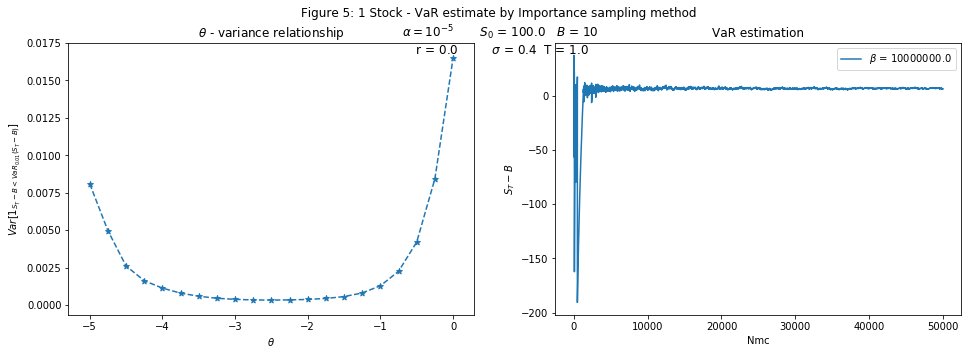

```python
Nmc = 20000

theta = np.linspace(-5,0,21)
variance = np.zeros((len(theta),1))
S = np.zeros((Nmc,1))
radon = np.zeros((Nmc,1))
w = np.zeros((Nmc,1))
ex = np.zeros((Nmc,1))
ex_2 = np.zeros((Nmc,1))

for theta_i in range(0,len(theta)):
    for n in range(0,Nmc):
        w[n] = T[0]**0.5*np.random.normal()
        S[n] = So*np.exp((r-0.5*sigma**2.0)*T[0]+sigma*(w[n] + theta[theta_i]*T[0]))
        radon[n] = np.exp(-theta[theta_i]*w[n]-0.5*T[0]*theta[theta_i]**2.0)

        if S[n] - 10.0 <= 26.43:
            ex[n] = radon[n]
            ex_2[n] = radon[n]**2.0

    variance[theta_i] = ex_2.mean() - ex.mean()**2.0

plt.subplots(figsize = (16,5))
plt.subplot(1,2,1)
plt.plot(theta, variance, linestyle = 'dashed')
plt.scatter(theta, variance, marker = '*')
plt.xlabel(r'$\theta$')
plt.ylabel(r'$Var[1_{S_T-B < VaR_{0.01}(S_T-B)}]$')
plt.title(r'$\theta$ - variance relationship')

theta_0 = theta[np.where(variance == min(variance))[0]]
s=0
alpha = 10.0**-5.0
beta = [100.0/alpha]
var_rb_is = np.zeros((Nmc+1,len(beta)))

for beta_i in range(0,len(beta)):
    for n in range(0,Nmc):
        w[n] = T[0]**0.5*np.random.normal()
        gamma = beta[beta_i]/(n+2)**lamda
        S[n] = So*np.exp((r-0.5*sigma**2.0)*T[0]+sigma*(w[n] + theta_0*T[0]))
        radon[n] = np.exp(-theta_0*w[n]-0.5*T[0]*theta_0**2.0)

        var_rb_is[n+1,beta_i] = var_rb_is[n,beta_i] - gamma*(phi(var_rb_is[n,beta_i], S[n]- 10.0)*radon[n] - alpha)

        if (var_rb_is[n+1,beta_i] >= -d*log(1+s)) & (var_rb_is[n+1,beta_i] <= d*log(1+s)):
            s = s
        else:
            var_rb_is[n+1,beta_i]=var_rb_is[0,beta_i]
            s = s+1


plt.subplot(1,2,2)
plt.plot(var_rb_is)
plt.ylabel(r'$S_T-B$')
plt.xlabel('Nmc')
plt.legend([r'$\beta$ = '+str(beta[0])])
plt.title('VaR estimation')

plt.suptitle('Figure 5: 1 Stock - VaR estimate by Importance sampling method \n' + r'$\alpha = 10^{-5}$' + '\t $S_0$ = ' + str(So) + '\t $B$ = ' + str(10) + '\n r = ' +str(r) + '\t $\sigma$ = ' +str(sigma) + '\t T = '+ str(T[0]) + '\n')

print('VaR = ' + str(np.round(var_rb_is[-1,0],2)))
```

## 2.2. Risk of a portfolio of stocks

### 2.2.1. Loss from a portfolio of stocks

It is a general consensus that you never put all eggs in one basket. Thus, investors are more interested in a portfolio of stocks than a single stocks because they can benefit from diversified risk. In this section, we tackle a portfolio of N=125 stocks, each shares the same parameters $S_0=100$ and the interest rate $r=0$.

First, we study a homogeneous portfolio where all stocks share same volatility $\sigma=0.4$ in $T=1$ year, each stock is independent of another and has the same recovery rate $R=0.3$. Recovery rate is the percentage of loss that we can "recover" in case of default. Hence, its complement $1-R$ is an estimate for Loss Given Default (LGD). The loss of the portfolio is the average loss of stocks. \begin{equation} X=\frac{1}{N} \sum\limits_{i=1}^{N} S_T^i-B \tag{11} \end{equation}

Figure 6 compares the loss distribution between a single stock and a portfolio of stocks. It depicts that the loss distribution of a single stock has fatter tail than that of the portfolio. This implies that portfolio's variance, or its risk, is less than a single stock's.

[figure not shown]

```python
Nmc = 10000
N = [1,125]
So = 100.0
B = 36
sigma = 0.4
r = 0.0
T = 1.0
t = np.linspace(0,T,np.int(T*365.0)+1)
dt = 1.0/365.0
X = np.linspace(-100, 200, 301)

density = np.zeros((301,len(N)))
cumul = np.zeros((301,len(N)))
loss = np.zeros((Nmc,1))

for k in range(0,len(N)):
    S = np.zeros((Nmc,N[k]))
    for n in range(0,Nmc):
        for i in range(0,N[k]):
            S[n,i] = evolve(So,r,sigma,T)[0] - B

        loss[n] = S[n,:].mean()

    for x in range(0,len(X)):
        density[x,k] = sum(1.0 for s in loss[:,0] if (s <= X[x] + 1) & (s > X[x]))/float(Nmc)
        cumul[x,k] = sum(1.0 for s in loss[:,0] if s <= X[x])/float(Nmc)

plt.subplots(figsize=(16,5))
plt.subplot(1,2,1)
plt.plot(X, density)
plt.xlabel(r'$S_T-B$')
plt.ylabel('Probability')
plt.title('Density')
plt.legend(['N=1', 'N=125'])

plt.subplot(1,2,2)
plt.plot(X, cumul)
plt.xlabel(r'$S_T-B$')
plt.ylabel('Probability')
plt.title('Cumulative')
plt.legend(['N=1', 'N=125'])

plt.suptitle('Figure 6: N Stock - Loss distribution of N independent homogeneous stocks \n B=36' + r'$S_0$ = ' + str(So) + '\t r = ' +str(r) + '\t $\sigma$ = ' +str(sigma) + '\t T = '+ str(T))
plt.show()
```

### 2.2.3. The number of bankruptcies

Other than the loss distribution of the portfolio, the number of bankruptcy $L$ in the portfolio is another aspect that draws our attention: \begin{equation} L=\sum\limits*{i=1}^N1*{S_T^i<B} \tag{12} \end{equation}

Figure 7 sketches the right-tail of the distribution of the number of bankruptcy $P(L\geq K)$ for 3 different thresholds $B$. A common feature in this graph is the downward sloping of the distribution. It is rational in the way that it is less likely to have many defaults in the portfolio. The graph also suggests that lower $B$ leads to a lower probability to have at least K bankruptcies. For example, $P(L\geq 10)\approx 0\%$ for $B=36$, it goes up to $30\%$ for $B=50$ and it is almost surely that $L\geq 10$ when $B=100$.

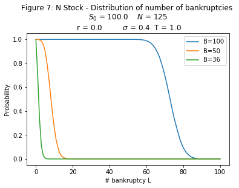

```python
Nmc = 10000
N=125
B = [100.,50.,36.]
l = np.linspace(0,100,101)

dist = np.zeros((len(B), len(l)))
L = np.zeros((Nmc,1))
S = np.zeros((Nmc,N))
for b in range(0,len(B)):
    for n in range(0,Nmc):
        for i in range(0,N):
            S[n,i] = evolve(So,r,sigma,T)[0]

        L[n] = sum(1.0 for s in S[n,:] if s <= B[b])
    for li in range(0,len(l)):
        dist[b,li] = sum(1.0 for s in L[:,0] if s >= l[li])/float(Nmc)

plt.plot(l, dist.transpose())
plt.xlabel('# bankruptcy L')
plt.ylabel('Probability')
plt.legend(['B=100', 'B=50', 'B=36'])
plt.title('Figure 7: N Stock - Distribution of number of bankruptcies \n' + r'$S_0$ = ' + str(So) + '\t $N$ = ' + str(N) + '\n r = ' +str(r) + '\t $\sigma$ = ' +str(sigma) + '\t T = '+ str(T))
```

### 2.2.4. Recovery of the loss

Afore, we have only pondered the "loss" facet of our portfolio: the PD and the number of default. Nonetheless, when a company goes bankrupt, it can liquidate its remaining assets and pay back a part of its debt. The remaining debt $\Pi_T$ that can be "recovered" is define as: \begin{equation} \Pi*T=\sum\limits*{i\in D_T} R_i S_T^i \text{ where } D_T:={1\leq i\leq N|S_T^i - B \leq0} \tag{13} \end{equation}

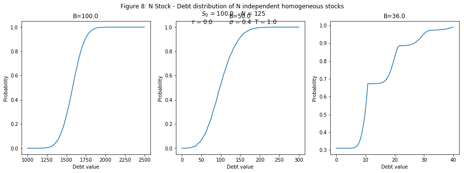

```python
recovery = 0.3
xlim = [[1000,2500],[0,300],[0,40]]
D = np.zeros((Nmc,1))

plt.subplots(figsize = (16,5))
for b in range(0,len(B)):
    x = np.linspace(xlim[b][0], xlim[b][1], 101)
    dist = np.zeros((len(B), len(x)))
    for n in range(0,Nmc):
        for i in range(0,N):
            S[n,i] = evolve(So,r,sigma,T)[0]

        D[n] = sum(s*recovery for s in S[n,:] if s <= B[b])
    for xi in range(0,len(x)):
        dist[b,xi] = sum(1.0 for s in D[:,0] if s <= x[xi])/float(Nmc)

    plt.subplot(1,3,b+1)
    plt.plot(x, dist[b,:].transpose())
    plt.xlabel('Debt value')
    plt.ylabel('Probability')
    plt.title('B='+str(B[b]))

plt.suptitle('Figure 8: N Stock - Debt distribution of N independent homogeneous stocks ' + r'$S_0$ = ' + str(So) + '\t $N$ = ' + str(N) + '\n r = ' +str(r) + '\t $\sigma$ = ' +str(sigma) + '\t T = '+ str(T))
```

Next, we study the conditional expectation of the remaining debt value $\Pi_T$ given the number of bankrupted company $L$: $E[\Pi_T|L>K]$.

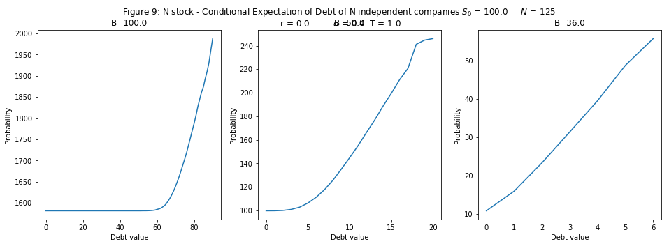

```python
xlim = [[0,100],[0,25],[0,8]]
D = np.zeros((Nmc,1))
L = np.zeros((Nmc,1))
S = np.zeros((Nmc,N))

plt.subplots(figsize = (16,5))

for b in range(0,len(B)):
    x = np.linspace(xlim[b][0], xlim[b][1], xlim[b][1] + 1)
    dist = np.zeros((len(B), len(x)))

    for n in range(0,Nmc):
        for i in range(0,N):
            S[n,i] = evolve(So,r,sigma,T)[0]

        L[n] = sum(1.0 for s in S[n,:] if s <= B[b])
        D[n] = sum(s*recovery for s in S[n,:] if s <= B[b])

    for xi in range(0,len(x)):
        idx = np.where(L >= x[xi])[0]
        if len(idx) != 0:
            dist[b,xi] = sum(D[idx])/(len(idx))
        else:
            dist[b,xi] = np.NaN
    plt.subplot(1,3,b+1)
    plt.plot(x, dist[b,:].transpose())
    plt.xlabel('Debt value')
    plt.ylabel('Probability')
    plt.title('B='+str(B[b]))

plt.suptitle('Figure 9: N stock - Conditional Expectation of Debt of N independent companies ' + r'$S_0$ = ' + str(So) + '\t $N$ = ' + str(N) + '\n r = ' +str(r) + '\t $\sigma$ = ' +str(sigma) + '\t T = '+ str(T))
```

Figure 9 illustrates 3 different lines for the conditional expectation of debt for 3 different threshold $B=36,50,100$ knowing the number of bankruptcies. We can see that the conditional expectation is increasing. This is obviously true as the higher the number of bankruptcy, the higher the value of the debt. However, when $B=100$, the expectation of debt is much higher compared to the two other cases. $E[\Pi_T|L>0]$ when $B=100$ is almost 1600, which means if there is any case of bankruptcy, you are expected to have the recovered debt of 1600, but for $B=50$ and $B=36$, there are only about 100 and 10 respectively.

### 2.2.5. Brownian motion's correlation effect to stocks portfolio

Stocks may moves somewhat in relation to each other. Thus, it is crucial to study the effect of correlation to our hypothetical portfolio. Now supposing our N dimensional Brownian motion $W_T$ is positively correlated with correlation coefficient $\rho$. We apply Cholesky method to decompose this vector to an uncorrelated Brownian motion $B_T$: $$W^i_T=\sum\limits_{j=1}^N M_{ij}B^i_T$$ Then, the stock price is given as \begin{equation} S^{(i)}_t=S^{(i)}_0 \exp \Big(\big(r-\frac{\sigma_i^2}{2})t+\sigma*i \sum\limits*{j=1}^{N}M_{ij}B^j*t\Big) \text{ $i \leq N$} \tag{14} \end{equation} where $M*{ij}$ is our Cholesky lower matrix $$ MM^T=Cov=\left ( {\begin{array}{ccccc} 1 & \rho & ... & ... & \rho\\ \rho & 1 & \rho & ... & \rho\\ ... & ... & ... & ... & ... \\ \rho & ... & ... & \rho & 1 \end{array} } \right) $$ So in order to calculate the risk distribution and indicator, we only need to replace $W*T$ with $\sum\limits*{j=1}^N M_{ij}B^i_T$ and all of the functions now will be based on the new independent Brownian Motion $B_T$.

## 2.3 Estimate IS parameter by R-S algr.

Beforehand, we have studied the link between $\theta$ and variance by the "smile". Another method proposed by Lelong (2007) is to endorse Robbins-Monro algorithm to minimize the variance of a targeted function, or to find the point where the gradient is zero.

\begin{equation} E\Big[(\theta T-W_T)\phi (W_T)^2 e^{-\theta W_T+\frac{\theta^2 T}{2}}\Big]=0 \tag{15} \end{equation}

```
$\theta$ = -1.31
VaR = -83.02
$\theta$ = -1.31
VaR = -83.45
```

[figure not shown]

```python
Nmc = 20000
T = 1.0
B = 100.0
alpha = 10.0**-5.0

theta = np.zeros((Nmc+1,len(beta)))
S = np.zeros((Nmc,1))
beta = [100.0, 10.0]
theta_0 = np.zeros((len(beta), 1))

plt.subplots(figsize = (16,5))
for beta_i in range(0,len(beta)):
    theta[0,beta_i] = -1.
    d = 1.
    s = 0.
    for n in range(0,Nmc):
        gamma = beta[beta_i]/(n+2)**lamda
        w[n] = T**0.5*np.random.normal()
        S[n] = So*np.exp((r-0.5*sigma**2.0)*T+sigma*(w[n] + theta[n,beta_i]*T))

        theta[n+1,beta_i] = theta[n,beta_i] - gamma*(phi(-63, S[n]-B)**2.0*((theta[n,beta_i]*T-w[n])*np.exp(-theta[n,beta_i]*w[n]+0.5*theta[n,beta_i]**2.0*T)))

        if (theta[n+1,beta_i] >= -d*log(1+s)) & (theta[n+1,beta_i] <= d*log(1+s)):
            s = s
        else:
            theta[n+1,beta_i]=theta[0,beta_i]
            s = s+1.

    theta_0[beta_i] = theta[-1,beta_i]

Nmc = 50000
beta = [1.0/alpha, 10./alpha]
var_rb_is = np.zeros((Nmc+1,len(beta)))
S = np.zeros((Nmc,1))
w = np.zeros((Nmc,1))
radon = np.zeros((Nmc,1))

for beta_i in range(0,len(beta)):
    d = 20.
    s = 0.
    var_rb_is[0,beta_i] = 10.0
    for n in range(0,Nmc):
        gamma = beta[beta_i]/(n+2)**lamda
        w[n] = T**0.5*np.random.normal()
        radon[n] = np.exp(-theta_0[beta_i]*w[n]-0.5*T*theta_0[beta_i]**2.0)
        S[n] = So*np.exp((r-0.5*sigma**2.0)*T+sigma*(w[n] + theta_0[beta_i]*T))

        var_rb_is[n+1,beta_i] = var_rb_is[n,beta_i] - gamma*(phi(var_rb_is[n,beta_i], S[n]- B)*radon[n] - alpha)

        if (var_rb_is[n+1,beta_i] >= -d*log(1+s)) & (var_rb_is[n+1,beta_i] <= d*log(1+s)):
            s = s
        else:
            var_rb_is[n+1,beta_i]=var_rb_is[0,beta_i]
            s = s+1.

    print(r'$\theta$ = ' + str(np.round(theta[-1,beta_i],2)))
    print('VaR = ' + str(np.round(var_rb_is[-1,beta_i],2)))

plt.subplot(1,2,1)
plt.plot(theta)
plt.ylabel(r'$\theta$')
plt.xlabel('Nmc')
plt.title(r'$\theta$ estimation')

plt.subplot(1,2,2)
plt.plot(var_rb_is)
plt.ylabel(r'$S_T-B$')
plt.xlabel('Nmc')
plt.legend([r'$\beta$ = '+str(beta[0])])
plt.title('VaR estimation')

plt.suptitle('Figure 10: Robbins-Monro method application in estimating theta \n' + r'$\alpha = 10^{-5}$' + '\t $S_0$ = ' + str(So) + '\t $B$ = ' + str(10) + '\n r = ' +str(r) + '\t $\sigma$ = ' +str(sigma) + '\t T = '+ str(T))
```

# Reference

Lelong, J.,PhD. Thesis, Etude asymptotique des algorithmes stochastiques et calcul des prix des options Parisiennes (2007)